# Surrogación semiótica y fluidez intertemática: Peirce entre cargas inferenciales creativas y subitez innovadora

Autores/as

Afiliación

Aída Sandra Visokolskis

Universidad Nacional de Córdoba

Rocío Janet Dalio

Universidad Nacional de Córdoba

Resumen

El presente trabajo se ocupa de relacionar dos conceptos que Peirce trabajó en torno a los procesos creativos en las ciencias, y que, por sus características propias, tienden a considerarse polos opuestos de lo mismo: por un lado, lo que hoy se ha dado en llamar “surrogación” en dominios semióticos ((Swoyer, 1991), (Barwise y Shimojima, 1995), (Contessa, 2007), (Redmond y López-Orellana, 2022), (Redmond y López-Orellana, 2023), entre otros), y, por el otro lado, el estado de inmediatez que se suele atribuir a intuiciones cuando se las considera a éstas como directas y no precedidas por ningún conocimiento, descripto así en un estilo claramente cartesiano y contrario a Peirce (CP 5.213, 1868; CP 5.259-5.263, 1868), aunque en lo que sigue no entendido como tal, denominado aquí, “subitez innovadora” o “insight creativo” (Mayer 1992, Dominowski & Dallob 1995, Kounios & Jung-Beeman 2009, Nęcka 2011, Vartanian 2011, entre muchos otros). El contexto donde Peirce asentó ambos conceptos, trabajados por él, aunque con la asignación de otros nombres, fue el de los razonamientos abductivos. En efecto, como es bien sabido, la abducción para Peirce es el único razonamiento que introduce novedad (CP 5.172, 1903), siendo por tanto aquel que aporta creatividad ((Anderson, 1987), (Nubiola, 2005), (Barrena, 2007), (Barrena, 2019), (Barrena y Nubiola, 2020), (Barrena y Nubiola, 2023), Arfini 2023, Campos 2023, Ernest 2023, Paavola 2023, (Reyes Cárdenas y Flórez Restrepo, 2025), (Visokolskis, 2009), (Visokolskis, 2016), (Visokolskis y Carrión, 2019), (Visokolskis, 2021), (Visokolskis, 2023a), (Visokolskis, 2024a), (Visokolskis, 2024b), Visokolskis 2025). El objetivo del trabajo es analizar críticamente el salto cualitativo que parece haber en los razonamientos abductivos en procesos creativos, que, por un lado, son claramente mediatizados inferencialmente por alguna información ampliativa extra introducida a través de signos apropiados, y, por otro lado, de manera inesperada y sorpresiva, aportan instantáneamente datos nunca antes obtenidos. Esta ruptura aparente podría eventualmente disolverse a partir de la introducción de razonamientos asociativos previamente realizados antes del salto abductivo, razonamientos que, compuestos, conforman lo que hemos dado en llamar “transducción” ((Visokolskis, 2009), (Visokolskis, 2016), (Visokolskis y Carrión, 2019), (Visokolskis, 2021), (Visokolskis, 2023a), (Visokolskis, 2024a), Visokolskis 2024, Visokolskis 2025), como complemento de la abducción peirceana, propuesta que se presenta seguidamente.

# Introducción

En la temática inferencial, Peirce ha recorrido un largo camino de más de treinta años, reformando, entre otras cosas, su noción de abducción, aportando, en este proceso, diversas variantes de la misma ((Thagard, 1988), (Magnani, 2001), 2009, Gabbay & Woods 2005, (Niño, 2007), (Schurz, 2008), 2017, Hoffmann 2011, Park 2015, Minnameier 2017, (Flórez Restrepo, 2021), (Visokolskis, 2023b)). Dentro de las características que Peirce atribuye a la abducción, resultan notables dos propiedades que aparentan pertenecer a las antípodas del mismo concepto: mediatez e instantaneidad. En efecto, por un lado, Peirce asume que la abducción es un tipo de razonamiento, el único capaz de introducir novedad. Como tal, la abducción permite formular una hipótesis plausible expresable, por ejemplo, en términos silogísticos a través de un proceso mediatizado precisamente por el término medio. Y en el caso de argumentos en formatos y formulaciones lógicas más actuales, por cierto, tal mediatización la proveen elementos de las premisas en variados formatos. Hasta aquí la idea trivial de mediatez en torno a la abducción.

Pero, por otro lado, la abducción peirceana expuesta por ejemplo en textos suyos de comienzos del siglo XX, se presenta como un insight instantáneo y fugaz, un destello de ideas, un momento súbito: “La sugestión abductiva nos llega como un rayo. Es un acto de introvisión, aunque extremadamente falible” (Peirce, CP 5.181, 1903). Esto último es reforzado por Peirce, por la idea de que la formación de hipótesis, i.e., una propiedad de la abducción, se debe a un especial “instinto para conjeturar” (Peirce, CP 1.80, c. 1896; CP 1.630, 1898; CP 6.475, 1908; EP 2: 472, 1913). Así, la actividad creativa, en manos de Peirce, se ubica entre dos polos: lo mediatizado y lo instantáneo, cubriendo ambos, diferentes funciones en los procesos innovadores. La aparente ambigüedad en torno a estas dos características de la creatividad, plasmada a partir de la inferencia abductiva, por un lado, ha sido también planteada por la filosofía de la ciencia, en términos de lo que se ha dado en llamar “razonamiento surrogatorio”, i.e., por el lado de la mediatez. Y, en términos de una intuición cartesiana, inmediata, directa y no precedida por conocimientos previos, por el lado de la instantaneidad.

En lo que sigue, la sección segunda se ocupa de la noción de surrogación (o subrogación) y su incidencia en la obra peirceana. A su vez, la sección tercera se ocupa de

la noción de fluidez intertemática ((Dalio, 2022a), (Dalio, 2022b), (Dalio, 2022c), 2023a, b, (Dalio, 2024), (Visokolskis et al., 2020a), (Visokolskis y Dalio, 2023)) a los fines de ofrecer una explicación sinequista peirceana del traspaso creativo (tanto inferencial como intuitivo experto) de un no conocimiento a un conocimiento creativo, original e innovador.

El objetivo de mostrar las discusiones en torno a estos dos polos opuestos en los trabajos peirceanos, consiste en ofrecer una manera complementaria de ubicar a la abducción dentro de los procesos creativos, no ya como el único tipo de razonamiento que introduce novedad[^1], sino acompañado de manera cooperativa, de otros procesos inferenciales previos, que se orientan a describir la formación de hipótesis no ya basada sólo en el instinto que Peirce arguye, sino que conjuntamente con la abducción, existirán otros razonamientos más que complementan lo dado, introduciendo allí nuestra idea de “transducción”. De esta manera, culminamos el trabajo con una explicación argumentativa en favor de la transducción para evitar caer en las conocidas paradojas que asumimos que enfrenta la ambigüedad entre mediatez e instantaneidad.

# La noción de surrogación y su incidencia en la obra peirceana

En lo que sigue entenderemos la creatividad en términos de resolución de problemas. No todo problema requiere de habilidades creativas para su consecución, dado que hay casos donde se producen resultados sin demasiada dificultad, sólo escarbando elementos dentro del mismo contexto en el que se plantea y se formula dicho problema. De estos casos no nos ocuparemos. Sólo interesa analizar situaciones donde el problema A a resolver esté en un estado tal que aparentemente ninguna información más pueda extraerse desde su propio entorno. Se hace pues necesario ejercer algún tipo de actividad creativa que genere elementos externos al propio A, del que ya en apariencia nada más se puede obtener para resolverlo. Esto lleva naturalmente a iniciar búsquedas exógenas a A, surrogando así la tarea a otro contexto B oportuno, pero previamente conocido.

Este proceso de surrogación implica al menos dos cosas: por un lado, el dominio B es evocado como instrumento externo que, se asemeja por analogía con las características internas propias de A, generando así, en paralelo, un *punto de vista novedoso* desde donde mirar a A. Por otro lado, esta óptica diferente provee de un *aparato representacional* diferente del de A, aunque con ciertas características que lo hacen funcionalmente similar. Así, se busca B en aras a trasladar la solución del problema familiar B posiblemente por analogía al de A, pero tal solución, expresada en otros términos, con el objetivo de suministrar herramientas antes no utilizadas con tal fin. Estos serían entonces los dos sentidos en que entenderemos el término “surrogación”: (1) evocación de una perspectiva externa desde donde mirar con otra óptica, y (2) provisión de un sistema representacional desde donde asentar las ideas de A que se buscan esclarecer vía elementos de B.

Dentro de los filósofos de la ciencia que trataron en un principio el tema de la surrogación, Jon Barwise y Atsushi Shimojima presentaron tempranamente en 1995 un artículo titulado *Surrogate Reasoning*, que esquematiza el tratamiento de la surrogación en términos de resolución de problemas a partir de procesos de razonamiento, expresando con ello que: “El razonamiento es el proceso mediante el cual uno comienza con un problema e intenta llegar a una solución” ((Barwise y Shimojima, 1995), p. 7), a partir de valorar un problema como una fuente de incerteza, cuya resolución consiste en contemplar elementos externos al problema mismo para intentar disolver las dificultades que llevaron a no poder resolverlo con técnicas y recursos propios del mismo contexto problemático. Este tipo de artificio metodológico recibe el nombre de “razonamiento surrogatorio” por parte de estos autores, que tiene “el potencial de aclarar, desenredar y enriquecer el contenido de los modelos que se están desarrollando” (op. cit.: 26). ¿Cuáles serían por caso tales herramientas externas? “Lápiz y papel [o tiza y pizarrón], calculadoras, computadoras, oraciones, diagramas, modelos físicos, modelos matemáticos y expertos humanos” (op. cit.: 8), así como “imágenes y máquinas” (op. cit.: 26). Las mismas aportan la apertura a nuevas situaciones dentro del dominio A dado, que antes eventualmente no hubieran podido captarse. Esto, a su vez, trae aparejadas varias ventajas, como, por ejemplo, un sistema notacional mejorado, un marco teórico más amplio donde desplegar de manera generalizada los al parecer escuetos supuestos que gobernaban A, un “cambio de enfoque, (…) [que]”podría dar un nuevo enfoque a viejos problemas” (op. cit.:10), o un enfoque de A diverso que amplifica los resultados a obtener, entre otras cosas.

En relación con este último tópico, el artículo de Chris Swoyer ((Swoyer, 1991)), considerado el primero en su línea de investigación acerca de la surrogación dentro del marco de la filosofía de las ciencias, aporta una estructura común entre la representación B y lo representado A, denominada por Swoyer “representación estructural”, un tipo de relación, digamos M, entre B y A, en ese orden, que lleva a proceder a través de los siguientes pasos:

(1°) Introducción de una representación B de un problema A.

(2°) Examen y manipulación del comportamiento de los elementos de B similares a otros en paralelo en A, sin riesgo de hacerlo sobre los originales elementos en A, evitando así consecuencias quizás nefastas sobre A (Swoyer cita el caso de B siendo un modelo a escala de un avión en el túnel de viento, a diferencia de A siendo un avión real Boeing 747 sobre el cielo de Denver).

(3°) Extracción de conclusiones C<sub>B</sub> sobre la representación B.

(4°) Traducción de tales conclusiones C<sub>B</sub> sobre A, resultando en las conclusiones C<sub>A</sub> útiles para resolver A: “Creo que un punto central de muchas representaciones es que nos permite razonar directamente sobre una representación para sacar conclusiones sobre algún fenómeno que representa” ((Swoyer, 1991), p. 450).

Las expresiones que Swoyer utiliza para caracterizar el término medio común M entre los dominios A y B son: estructura común, estructura compartida, patrón común ((Swoyer, 1991), p. 451), produciendo una “similaridad de estructura” ((Swoyer, 1991), p. 452). Por tanto, la relación entre B y A asimétrica, resulta de semejanza estructural. Podemos agregar, sin ánimo a diferir con Swoyer que la extracción de consecuencias C<sub>A</sub> sobre A a partir de la semejanza con el resultado C<sub>B</sub> en B, es una relación como mínimo de transferencia analógica, y, como máximo, de isomorfismo, que, en el caso analógico, así lo indica el diagrama de la figura 1, caso que tomaremos como prototípico en nuestro análisis:

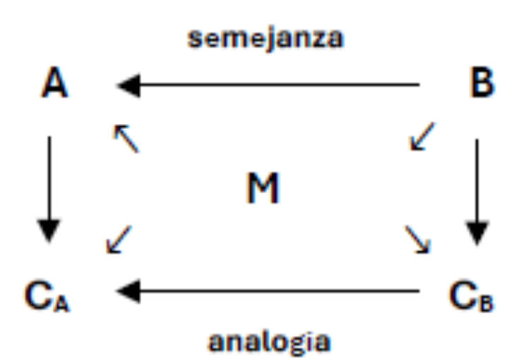

Figura 1

Para asimilar mejor dicho esquema, a continuación, describimos diagramáticamente en la figura 2, un ejemplo del propio Swoyer: “Al usar números para representar las longitudes de objetos físicos, podemos representar numéricamente hechos sobre los objetos, realizar cálculos de varios tipos y luego traducir los resultados a una conclusión sobre los objetos originales” ((Swoyer, 1991), p. 449).

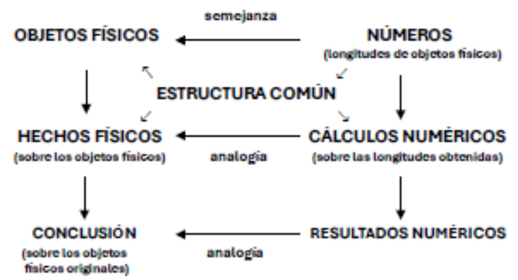

Figura 2

El razonamiento surrogatorio que opera para detectar una posible solución C<sub>A</sub> al problema A, proporciona la alternativa a salirse del contexto original A, evocando otro medio B del que conocemos su solución C<sub>B</sub>. Esto permitiría facilitar la búsqueda: “(…) el punto en cada caso es el mismo: representar algo en un medio que facilite *la inferencia* sobre ello” ((Swoyer, 1991), p. 451; las itálicas son nuestras). Y, también permitiría introducir creativamente novedad: “[El] marco puede ser fructífero (…) ya que es probable que *aún sugiera nuevas preguntas* sobre el fenómeno y *proporcione nuevos conceptos y técnicas* para su estudio” ((Swoyer, 1991), p. 476).

Gabriele Contessa, en su trabajo de 2007 agrega que, según Mauricio Suárez (2004), un razonamiento surrogatorio debe cumplir con la condición de permitir extraer conclusiones a partir de la homologación entre dominio representante y dominio representado ((Contessa, 2007), p. 49). Con lo cual, Suárez asignaría el carácter surrogatorio sólo a la producción de la transferencia analógica o, más aún, isomórfica; mientras que el proceso evocatorio que acerca B a A sería sólo denotativo. En este sentido, Contessa se basa críticamente en este planteo de Suárez para incorporar una perspectiva diferente respecto de la surrogación, que encuadra dentro de lo que creemos Peirce aceptaría en la construcción creativa de novedad abductiva. Veamos a continuación cómo resulta esto.

Contessa utiliza a la surrogación como un paso intermedio necesario para arribar a la conformación de “representaciones fehacientes y confiables” B de problemas A, puesto en nuestros términos. Tales representaciones adquieren el estatuto de símbolos en el esquema peirceano ((Peirce, 1931--1958), CP 2.292, MS 478, Syllabus).

La propuesta de Contessa considera completar la noción de surrogación con la de “representación”, aduciendo que utiliza la primera sólo como *síntoma* de la segunda. En este sentido, Contessa apela a una proporción metafórica que expresa esta idea: la surrogación es a la representación como el sarampión es a las manchas de Koplick. Cuando aparecen estas manchas en el organismo, son un síntoma de que algo sucede, un signo externo al dominio original A problemático, i.e. un signo de la existencia de otro dominio B surrogado. Pero, según Contessa ((Contessa, 2007)), la sola aparición del síntoma (manchas) no garantiza ni da lugar a la existencia de una genuina representación de A a través de B. Surrogación y representación están vinculadas biunívocamente según Contessa, en el sentido que las manchas (surrogación) aparecen si y sólo si uno tiene sarampión (representación). Pero esto no significa que uno tiene sarampión *porque* tiene estas manchas. Se necesita algo más que manchas para acceder a tal representación. De esta manera, según Contessa, este vínculo biunívoco entre surrogación y representación no necesariamente se da de manera *causal*. B denota a A pero puede que B no represente a A. Sólo lo hará en virtud del hecho que el usuario o agente *interprete* al vehículo B en términos del target A. Esto permitirá transformar a B en una representación de A, proveyendo de un cambio del punto de vista original a otra perspectiva que hace que B sea utilizado como una representación epistémica de A. Cabe observar que el modo cómo Contessa considera a la surrogación será de tipo indexical, dado que ésta opera en tareas representativas sólo aportando señales suficientes para proceder en la investigación científica señalando una posible semejanza. Como planteamos en la introducción, nuestra propuesta transductiva basada en Peirce parte precisamente de este tipo de surrogación indexical. Pero, siguiendo a Peirce en su habitual estilo triádico, proponemos tres signos surrogantes, y no sólo el indicial que plantea Contessa, tema desarrollado en la sección siguiente.

Consideramos que lo expresado por Contessa todavía es incompleto. Hace falta algo más, que, según nuestra interpretación transductiva es provista en otros términos respecto de los nuestros, por Juan Redmond y Rodrigo López-Orellana ((Redmond y López-Orellana, 2022), (Redmond y López-Orellana, 2023)). En diversos escritos, estos autores presentan una fundamentación dialógico-inferencial del razonamiento surrogatorio o “sustitutivo”, en un esfuerzo por ofrecer claridad a la relación entre lo surrogativo y lo representacional, que Contessa refiere como una relación “misteriosa e insondable como la adivinación” ((Contessa, 2007), p. 61).

Redmond y López-Orellana proponen tomar al problema sustituto o subrogado B “como si” fuera A, a partir de enunciados en B pero sobre A, en vistas a generar una solución C<sub>B</sub> de B que sería una solución indirecta de A, en vez de la directa C<sub>A</sub>, sin caer en el uso de una relación de representación (o, en todo caso, a la propuesta deflacionista representacionalista, pero inferencial de Mauricio Suárez (2004)). A tal fin, Redmond y López-Orellana proceden a lo Peirce, generando una hipótesis como solución falible del problema, buscando resolver dos cuestiones: (1) cómo opera el razonamiento surrogatorio y (2) cómo se genera una hipótesis a partir de la introducción del problema sustituto B, ambas cuestiones que Peirce también plantea, aunque en términos abductivos.

Es importante observar que Redmond y López-Orellana sólo se concentran en la generación de la hipótesis C<sub>A</sub>, lo mismo que Peirce, lo que en adelante denominamos “surrogación simbólica”. No obstante, consideramos que ambas propuestas no completan todo lo requerido para cerrar apropiadamente un circuito investigativo. También es importante advertir la presencia muchas veces no consciente de los nexos asociativos previos, que hemos dado en llamar “surrogación indexical” y “surrogación icónica”, como veremos más en detalle en la sección siguiente. De esta manera, la transducción resulta un razonamiento compuesto que consta de tres surrogaciones, donde la última resulta ser la abducción peirceana. En la sección siguiente, abordamos nuestra propuesta transductiva, que incluye, entre sus características, la incorporación de la noción de fluidez intertemática (en adelante FI) como explicación del tipo de nexo continuista entre la iniciación de un problema que requiere solución creativa y el momento aparentemente abrupto de la subitez innovadora.

# La propuesta: transducciones como transiciones fluidas. Un complemento para las abducciones

En otros textos anteriores hemos caracterizado a la transducción como una propuesta que busca partir de la abducción peirceana, pero insistiendo en la etapa de formación de hipótesis creativas científicas sin atender sólo a la idea instintiva peirceana que mencionáramos ut supra en sección 1, sino aportar instancias de índole asociativas, que aspiran a mantener una caracterización de tipo inferencial ya desde los primeros pasos de la investigación. En este sentido, caracterizamos dichos pasos inferenciales como tres clases de surrogaciones, recordando que, en la sección 2 mencionamos dos maneras en que entendemos la surrogación. La primera manera ha de desdoblarse en dos submodos: por un lado, la evocación de otro dominio B lisa y llanamente. Este fenómeno de aducir a otro contexto es ya de por sí suficiente acto surrogatorio, el cual llamamos “surrogación indexical”, aquella que ya observamos en Contessa ((Contessa, 2007)) aunque con otro nombre. Pero, además, la primera manera antes citada afirma la posibilidad de actuar desde el ángulo perceptual del nuevo dominio B, significando esto, también de por sí, un tipo diferente de surrogación, definida aquí como “icónica” por sus características que enseguida mencionaremos. Finalmente, la segunda manera de entender la surrogación provee de un tercer tipo: la “surrogación simbólica”, en acuerdo explícito con categorías semióticas peirceanas. Este tercer tipo de surrogación coincidiría presuntamente con el caracterizado por Redmond y López-Orellana.

Los razonamientos transductivos pasarían pues por tres etapas: la primera, de surrogación indexical, donde es evocado B a partir del problema original A a resolver creativamente, por contigüidad denotativa. La segunda etapa, de surrogación icónica requiere del cambio del punto de vista que hace que miremos a A desde la óptica de B, contribuyendo así con elementos antes no tenidos en cuenta, que describirían el problema A por rasgos de semejanza icónica, al estilo propuesto por Swoyer ((Swoyer, 1991)). Por último, el ciclo formador de hipótesis creativas se cierra con la contribución de la explicación abductiva peirceana, la surrogación simbólica. La figura 3 muestra este ciclo.

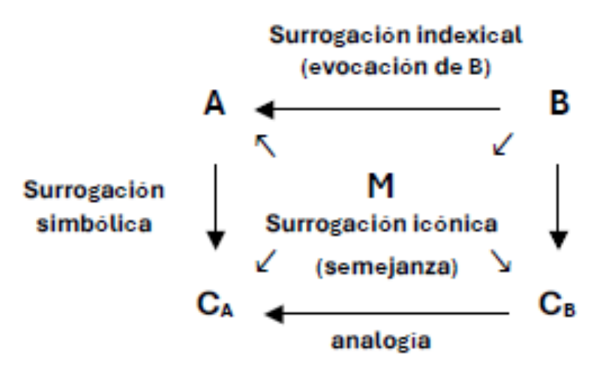

Figura 3

¿Cuál es el objetivo de hacer hincapié en etapas inferenciales asociativas previas a la abducción propiamente dicha? Rellenar huecos epistémicos con surrogaciones asociativas que se dan naturalmente, en vez de postular instintos sin más. Pero más aún, se busca mostrar cierta continuidad inferencial en los procesos creativos de formación de hipótesis. Tal continuidad inferencial es, además, una característica propiamente de los trabajos peirceanos, en el nombre de “sinequismo” (Peirce 1892, CP 6.103, EP 1:313; 1902, CP 5.4; 1898, CP 6.86; 1899, CP 7.535): “(…) la continuidad gobierna todo el dominio de la experiencia en cada elemento del mismo” (Peirce 1893, CP 7.565-566, EP 2:1). Es aquí, en este contexto donde proponemos resaltar una característica típica de los procesos creativos que hemos dado en llamar “fluidez intertemática” (FI). En efecto, en contextos creativos, donde la resolución de un problema A debe recurrir a factores externos al mismo, proveyendo de un dominio surrogado B, es relevante que fluya continuamente información de B a A a través del factor FI, y de la mano experta de un agente con conocimientos suficientes de tal dominio B. La fluidez tiene que ver con mostrar cómo es aparente la supuesta ruptura entre los procesos inferenciales abductivos que introducen novedad, y la idea de la existencia de un súbito insight.

Buscamos entonces, siguiendo el sinequismo peirceano, caracterizar tal aparente ruptura como un proceso continuo, imitando analógicamente la estrategia matemática de continuidad de la recta real, donde los números irracionales aparecen como el elemento que “rellena” los huecos que dejan los racionales en dicha representación rectilínea, cubriendo así los espacios vacíos que otrora existían en la descripción del número real. Y proponemos utilizar la noción de FI como nexo entre los procesos inferenciales abductivos innovadores y los insights de apariencia instantáneos, logrando conectar así continuamente ambos ámbitos: lo inferencial y lo intuitivo experto. Así la FI consistiría en un mecanismo cognitivo que actuaría como medio entre la formulación de un problema completo que requiere de estrategias resolutivas creativas y la emergencia de una conclusión que cierre el proceso creativo.

Tal FI proporciona una transición continua, en general no consciente y apenas perceptible, que busca explicar la inserción suave de razonamientos asociativos entre el planteo de un problema dificultoso sin aparente solución inmediata, y su resolución abductiva con aristas creativas.

# A modo de conclusión

A lo largo del trabajo hemos buscado caracterizar a la abducción peirceana como una tercera etapa de tres tipos de razonamientos surrogatorios, siguiendo estrategias investigativas de Barwise y Shimojima, Swoyer, Suárez, Contessa, y Redmond y López-Orellana en torno a la noción de surrogación científica. Esto haría de la abducción un grado de formación de hipótesis que operaría continuamente y de manera fluida con otros elementos asociativos previos, siguiendo el sinequismo peirceano.

## Referencias

Anderson, D.R. (1987), *Creativity and the Philosophy of C.S. Peirce*, Springer, Netherlands.

Barrena, S. (2007), *La razón creativa. Crecimiento y finalidad del ser humano según C. S. Peirce*, Rialp.

—— (2019), «Contributions of Charles S. Peirce to Creative Thinking», *Porto Arte: Revista de Artes Visuais*, 24(41).

Barrena, S., y J. Nubiola (2020), «Abduction: The logic of creativity», en: T. Jappy (ed.), *The Bloomsbury Companion to Contemporary Peircean Semiotics*, Bloomsbury, pp. 185-203.

—— (2023), «Creativity and Abduction According to Charles S. Peirce», en: L. Magnani (ed.), *Handbook of Abductive Cognition*, Springer.

Contessa, G. (2007), «Scientific Representation, Interpretation, and Surrogative Reasoning», *Philosophy of Science*, 74(1), 48-68.

Dalio, R.J. (2022a), «Herramientas Digitales y la Fluidez Intertemática en el Nivel Superior», *Revista Electrónica Internacional de Educación y Diversidad*, 2, 56-59.

—— (2022b), *La Fluidez Intertemática en el espacio de Expresiones Artístico-Culturales*, Ponencia presentada en II Congreso Internacional de Tecnología, Aprendizaje y Educación (CITAE), Chile.

—— (2022c), *La Fluidez Intertemática como mojón del Aprendizaje Creativo: Aportes de la Teoría Semiótica del Aprendizaje a la Flexibilización Curricular*, Ponencia presentada en XXIX Congreso Internacional de Aprendizaje, Valencia.

—— (2024), «Aproximaciones a la noción de Fluidez Intertemática», *Revista Internacional de Aprendizaje*, 11, 1-13.

Flórez Restrepo, J.A. (2021), «Are There Types of Abduction? An Inquiry into a Comprehensive Classification of Types of Abduction», en: J.R. Shook, S. Paavola (eds.), *Abduction in Cognition and Action. Logical Reasoning, Scientific Inquiry, and Social Practice*, pp. 3-30.

Magnani, L. (2001), *Abduction, Reason, and Science: Processes of Discovery and Explanation*, Kluwer, New York.

Niño, D. (2007), Abducting Abduction. Avatares sobre la comprensión de la Abducción de Charles S. Peirce, Tesis doctoral, Doctoral Thesis.

Nubiola, J. (2005), «Abduction or the logic of surprise», en: F. Merrell, J. Queiroz (eds.), *Abduction; between subjectivity and objectivity*, vol. 153, De Gruyter, pp. 117-130.

Peirce, C.S. (1931--1958), *Collected Papers of Charles Sanders Peirce*, 1-6 (Hartshorne & Weiss, eds.); 7-8 (Burks, ed.), 8 volumes, The Belknap Press of Harvard University Press, Cambridge, Massachusetts.

Redmond, J., y R. López-Orellana (2022), «¿Surrogative Reasoning as Representational or Logical-Based Thinking?», *ArtefaCToS. Revista de estudios de la ciencia y la tecnología*, 11(2), 191-207.

—— (2023), «Interactive Hypotheses: Towards a Dialogical Foundation of Surrogate Reasoning», *RHV*, 22, 105-130.

Reyes Cárdenas, P., y J.A. Flórez Restrepo (2025), «Mathematical Creativity: A Peircean Abductive Proposal», *Broad Research in Artificial Intelligence and Neuroscience (BRAIN)*, 16(1).

Schurz, G. (2008), «Patterns of abduction», *Synthese*, 164, 201-234.

Swoyer, C. (1991), «Structural Representation and Surrogative Reasoning», *Synthese*, 87(3), 449-508.

Thagard, P. (1988), *Computational Philosophy of Science*, The MIT Press, Cambridge, Massachusetts.

Visokolskis, A.S. (2009), «El fenómeno de la transducción en la matemática. Metáforas, analogías y cognición», en: A. Pochulu M. (ed.), *La metáfora en la educación. Descripción e implicaciones*, Eduvim, Villa María, pp. 37-53.

—— (2016), La noción de análisis como descubrimiento en la historia de la matemática. Propuesta de un modelo de descubrimiento creativo, Tesis doctoral, Facultad de Filosofía y Humanidades, Universidad Nacional de Córdoba, Córdoba, Argentina.

—— (2021), «Insightful yet Inferential Creativity: Transduction as a Derivation of Abduction», en: M.R. Galindo M. O. (ed.), *Proceedings of the Thirteenth Latin American Workshop on Logic/Languages, Algorithms and New Methods of Reasoning (LANMR 2020)*, CEUR Workshop Proceedings, Puebla, México, pp. 36-56.

—— (2023a), «Peirce en torno a mecanismos cognitivos con carga inferencial», en: I.V. Hynes C. & Gavriloff (ed.), *IX Jornadas "Peirce en Argentina"*, Sección de Lógica y Filosofía de la Ciencia de la Academia de Ciencias de Buenos Aires, Buenos Aires, pp. 115-125.

—— (2023c), *Creativity via Transduction: Associative Abductive Reasoning Through the Lens of Model-Based Reasoning*, Ponencia presentada en the Ninth International MBR Conference MBR023 Rome (Model-Based Reasoning in Science and Technology, Abductive Cognition, Creativity. Inferences & Models in Science, Logic, Language, and Technology). Sapienza, Universitá di Roma, Rome, Italy.

—— (2023d), *Are Associations Some Kind of Inferences? The Case for Creative Inferences*, Ponencia presentada en Symposium «What are Inferences? Some Reflections In-Between Logic, Language, and Cognition», 17th CLMPST Buenos Aires 2023, Buenos Aires.

—— (2023b), *La abducción en Peirce: ¿distintas versiones o compatibilidad en la diversidad?*, Ponencia presentada en Jornada de investigación de la cátedra de Gnoseología. Pragmaticismo y conocimiento. Facultad de Humanidades y Ciencias de la Educación, Universidad Nacional de La Plata, La Plata.

—— (2024a), *Metaphorical-Pragmatic Aspects of Knowledge in Peircean Writings: Creative Pre-sequences*, Ponencia presentada en Conference «Pragmatist Trends in Philosophy of Science and Mathematics (PTSM24)», University of East Anglia, Norwich, UK.

—— (2024b), *When Creativity Matters to Mathematical Practice: Behind-the-Scenes of Deductive Reasoning in Peirce*, Ponencia presentada en «7th International Meeting of the Association for the Philosophy of Mathematical Practice (APMP)», School for Advanced Studies IUSS, Pavia, Italy.

—— (s. f.a), «Imagination in the creative generation of logic and mathematics. Inferential and semiotic aspects», en: G.-K. Denisova T. (ed.), *Essays in Honor of Jean-Yves Béziau. Studies in Universal Logic (SUL)*, Springer Nature, Cham, Switzerland.

—— (s. f.b), «Deduction and Abstraction in Creative Imaginative Processes: The Peircean Solution», en: D. Beziau J.-Y. (ed.), *Imagination, Creativity, Intelligence. Proceedings Rio de Janeiro, December 9-13, 2024. In Memory of Newton da Costa (1929-2024). Studies in Universal Logic (SUL)*, Springer Nature, Cham, Switzerland.

Visokolskis, A.S., y G. Carrión (2010), «[Asociación de ideas en Peirce: de la psicología a la lógica](http://www.unav.es/gep/IVPeirceArgentinaVisokolskisCarrion.html)», en: C. Hynes (ed.), *Actas de IV Jornadas «Peirce en Argentina»*, Sección de Lógica y Filosofía de la Ciencia de la Academia Nacional de Ciencias de Buenos Aires, Buenos Aires.

—— (2018), «Creative Insights: Dual Cognitive Processes in Perspicuous Diagrams», en: Y. Sato, Z. Shams (eds.), *SetVR 2018, Set Visualization and Reasoning. Proceedings of International Workshop on Set Visualization and Reasoning, Volume 2116*, CEUR Workshop Proceedings, Edinburgh, United Kingdom, pp. 28-43.

—— (2019), «[La noción de semejanza en Peirce desde un punto de vista inferencial](http://www.unav.es/gep/JornadasPeirceArgentina.html)», en: C. Hynes (ed.), *Actas de VIII Jornadas «Peirce en Argentina»*, Sección de Lógica y Filosofía de la Ciencia de la Academia de Ciencias de Buenos Aires, Buenos Aires.

Visokolskis, A.S., y R.J. Dalio (2021), *Abducción, imaginación y musement en Peirce: relevancia del juego ocioso*, Facultad de Artes y Humanidades, Universidad de Caldas; Ponencia presentada en Segundo Congreso de la Sociedad Latinoamericana Peirce (Versión virtual), Caldas, Colombia.

—— (2023), *Interthematic Fluency as a Philosophical-Educational Category: A Proposal in Terms of Creativity*, Facultad de Ciencias Económicas, Universidad de Buenos Aires; Ponencia presentada en 17th CLMPST Buenos Aires 2023, The International Congress on Logic, Methodology, and Philosophy of Science and Technology, Buenos Aires.

Visokolskis, A.S., R.J. Dalio, y G. Carrión (2020a), *Orígenes de las fronteras interdisciplinares para la creatividad entre las artes y las ciencias: la noción de metábasis*, Universidad Nacional de Villa María; Ponencia presentada en las IV Jornadas de Investigación en Artes UNVM, Conversatorio «Desbordar las fronteras (Iniciativas interdisciplinarias en la UNVM)» (modalidad virtual), Villa María.

Visokolskis, A.S., E. Vargas, y G. Carrión (2020b), «Transductive Reconstruction of Hippocrates’ Dynamical Geometrical Diagrams», en: A. Pietarinen, P.L. Chapman Bosveld-de Smet, V. Giardino, J. Corter, S. Linker (eds.), *Diagrams 2020, LNAI 12169, Diagrammatic Representation and Inference*, Springer International Publishing, Cham.

## Notas

[^1]: Por cierto, el mismo Peirce hizo una ampliación en sus escritos posteriores, respecto de aquello que introduce novedad en los razonamientos, admitiendo que, además de la abducción, existe un tipo de razonamiento deductivo, el llamado “teoremático”, que aporta innovación. Si bien este tema no es tratado aquí por falta de espacio, está desarrollado en (Visokolskis 2022a, b, 2024c, d, e, 2025c, d, e).